# Item response models over time

```r
library(ctsem)
library(ggplot2)
```

A binary item measured repeatedly is an item response model whose latent ability moves. ctsem fits the two, three and four parameter logistic forms with `manifesttype = 1`, and the parameters map onto ones already in the model:

| IRT | ctsem | notes |
| --- | --- | --- |
| discrimination $a$ | `LAMBDA` | free loading |
| difficulty $b$ | `MANIFESTMEANS` | enters as $-ab$ |
| guessing $c$ | `ASYMPTOTES[, 'lower']` | lower asymptote |
| upper asymptote $d$ | `ASYMPTOTES[, 'upper']` | ceiling |

So the two parameter model needs no special argument at all. `ASYMPTOTES` has a row per binary item and a column for each asymptote. A cell left `NA` is no asymptote on that side, a number between 0 and 1 fixes it, and a name estimates it. Ordinal items are in the measurement models vignette; this one is about binary items and what has to be held fixed to estimate them.

# The response curves

$P(y=1 \mid \eta) = c + (d-c)\,\text{logit}^{-1}(a(\eta - b))$. The three forms differ only in where the curve starts and stops:

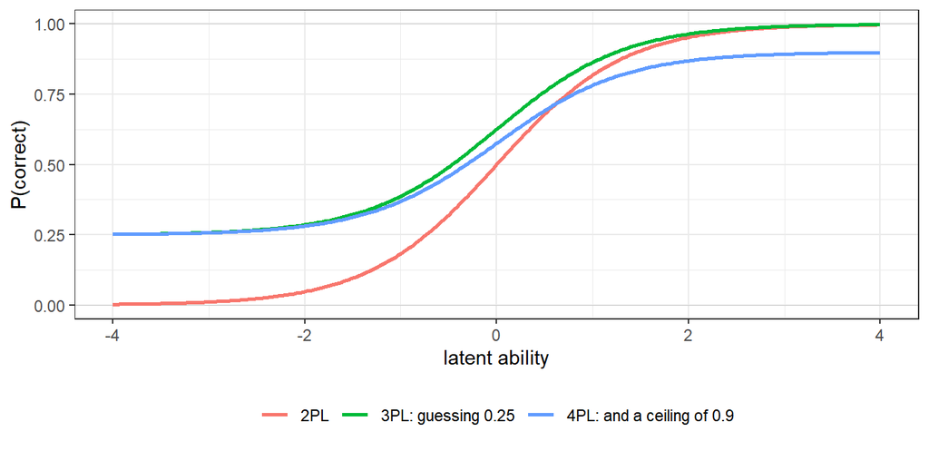

```r
eta <- seq(-4, 4, length.out = 300)
curve3 <- function(a, b, c, d, lab) data.frame(eta = eta, lab = lab,
  p = c + (d - c) / (1 + exp(-a * (eta - b))))

ggplot(rbind(
  curve3(1.5, 0, 0,    1,    '2PL'),
  curve3(1.5, 0, 0.25, 1,    '3PL: guessing 0.25'),
  curve3(1.5, 0, 0.25, 0.9,  '4PL: and a ceiling of 0.9')),
  aes(eta, p, colour = lab)) +
  geom_hline(yintercept = c(0, 1), linewidth = .3, colour = 'grey80') +
  geom_line(linewidth = 1) +
  scale_y_continuous(limits = c(0, 1)) +
  theme_bw() + theme(legend.position = 'bottom') +
  labs(x = 'latent ability', y = 'P(correct)', colour = NULL)
```

The guessing parameter lifts the floor: someone far below the item’s difficulty still answers correctly a quarter of the time. The upper asymptote lowers the ceiling, for items even able people sometimes miss.

# What has to be fixed

The latent process needs a **scale** and a **location**, as in any factor model, and the logistic link supplies neither. Multiply the process by $k$ and divide every discrimination by $k$ and the linear predictor is unchanged, so the likelihood cannot tell them apart.

There are two ways to pin the scale and they are the same model:

- **fix one loading** at 1 and let `DIFFUSION` be free, or
- **fix `DIFFUSION`** at 1 and let every loading be free.

What you cannot do is fix the latent *variance*, because in continuous time it is not a parameter: the stationary variance is $\text{DIFFUSION}^2/(2|\text{DRIFT}|)$, so constraining it would mean constraining a function of two things the model is estimating. Pick one of the two above instead.

For the location, leave `CINT` and `T0MEANS` at zero and let `MANIFESTMEANS` carry the difficulties. Freeing both ends is the same redundancy again.

`MANIFESTVAR` must be zero: the logistic link already supplies the randomness, and `ctFit()` fixes it for you if you leave it free.

# Simulating and fitting

Ten items with varying discriminations, 250 people, 8 occasions, guessing at 0.20.

```r
nitem <- 10
items <- paste0('y', seq_len(nitem))
a <- seq(0.9, 1.9, length.out = nitem)     # discriminations
b <- seq(-1.6, 1.6, length.out = nitem)    # difficulties
guess <- 0.20

gen <- ctModel(type = 'ct', n.latent = 1, n.manifest = nitem,
  manifestNames = items, latentNames = 'eta',
  manifesttype = rep(1, nitem), ASYMPTOTES = c(guess, NA),
  LAMBDA = matrix(a, nitem, 1), MANIFESTMEANS = matrix(-a * b, nitem, 1),
  DRIFT = matrix(-0.4), DIFFUSION = matrix(1.2), T0VAR = matrix(1.342),
  T0MEANS = matrix(0), CINT = matrix(0), MANIFESTVAR = diag(0, nitem),
  Tpoints = 8)

set.seed(7)
d <- data.frame(ctGenerate(gen, n = 250, Tpoints = 8, dtmean = 0.9,
  backend = 'julia'))
```

A length 2 vector, as here, fills every binary item’s row: the lower asymptote fixed at the guessing probability, and no upper one.

The floor is visible in the data. An item far above someone’s ability is still answered correctly about `c` of the time, where a 2PL would go to zero:

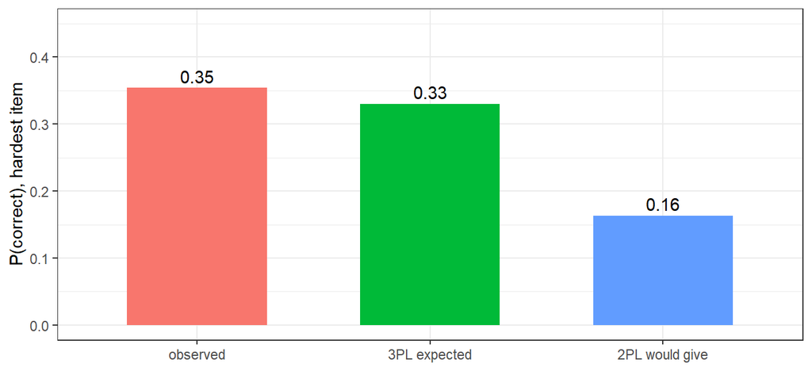

```r
hardest <- d[[items[nitem]]]
ggplot(data.frame(p = c(mean(hardest), guess +
    (1 - guess) * mean(plogis(a[nitem] * (rnorm(1e5, 0, 1.342) - b[nitem]))),
  mean(plogis(a[nitem] * (rnorm(1e5, 0, 1.342) - b[nitem])))),
  lab = factor(c('observed', '3PL expected', '2PL would give'),
    levels = c('observed', '3PL expected', '2PL would give'))),
  aes(lab, p, fill = lab)) +
  geom_col(width = .6, show.legend = FALSE) +
  geom_text(aes(label = sprintf('%.2f', p)), vjust = -0.4) +
  scale_y_continuous(limits = c(0, 0.45)) +
  theme_bw() + labs(x = NULL, y = 'P(correct), hardest item')
```

Fitting needs one argument changed between the models — `ASYMPTOTES`. A name in place of a number estimates that asymptote, and the same name on every item estimates one guessing parameter for the whole test. Per item is possible (`cbind(paste0('guess_', items), NA)`) and much harder to estimate; sharing is the usual starting point.

```r
irtmodel <- function(ASYMPTOTES = NA) {
  m <- ctModel(type = 'ct', n.latent = 1, n.manifest = nitem,
    manifestNames = items, latentNames = 'eta',
    manifesttype = rep(1, nitem), ASYMPTOTES = ASYMPTOTES,
    # Scale: the first loading is fixed at 1 and DIFFUSION is free.
    LAMBDA = matrix(c(1, paste0('a_', items[-1])), nitem, 1),
    # Location: the latent is centred, so MANIFESTMEANS are the difficulties.
    CINT = matrix(0), T0MEANS = matrix(0),
    MANIFESTVAR = diag(0, nitem))
  m$pars$indvarying <- FALSE
  m
}

fit2 <- ctFit(d[, c('id', 'time', items)], irtmodel(),
  backend = 'julia', cores = 1, priors = TRUE)
fit3 <- ctFit(d[, c('id', 'time', items)], irtmodel(c('guess', NA)),
  backend = 'julia', cores = 1, priors = TRUE)
```

```r
data.frame(model = c('2PL', '3PL'),
  loglik = round(c(fit2$estimate$loglik, fit3$estimate$loglik), 1),
  npars = c(length(fit2$estimate$raw), length(fit3$estimate$raw)),
  guess = c(NA, round(summary(fit3)$popmeans['guess', 'mean'], 3)),
  guess_sd = c(NA, round(summary(fit3)$popmeans['guess', 'sd'], 3)))
```

```
#>   model   loglik npars guess guess_sd
#> 1   2PL -11317.6    22    NA       NA
#> 2   3PL -11243.7    23 0.201     0.01
```

The guessing parameter is recovered with a usable standard error, and the three parameter model fits better for the one extra parameter.

# Reading the dynamics

The point of fitting these over time is the process, not the items. `ctDiscretePars()` gives the autoregression of ability across intervals:

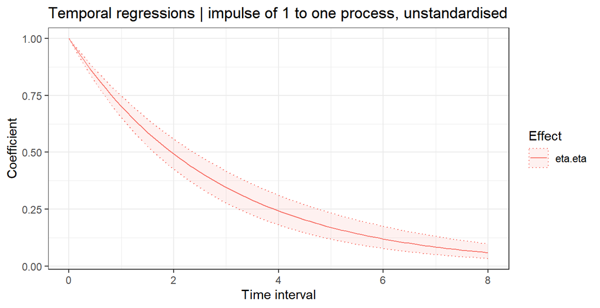

```r
ctDiscretePars(fit3, times = seq(0, 8, .1), plot = TRUE, indices = 'AR',
  cores = 1)
```

# Four parameters, and when to stop

Naming the second column frees the ceiling as well. Both are reported as the probabilities they are, and either can be estimated without the other — a ceiling alone, `c(NA, 'ceiling')`, is the model for items that able people sometimes slip on but nobody guesses.

```r
fit4 <- ctFit(d[, c('id', 'time', items)], irtmodel(c('guess', 'ceiling')),
  backend = 'julia', cores = 1, priors = TRUE)
round(summary(fit4)$popmeans[c('guess', 'ceiling'), ], 3)
```

```
#>          mean    sd  2.5%   50% 97.5%
#> guess   0.207 0.011 0.186 0.206 0.228
#> ceiling 0.986 0.007 0.969 0.987 0.995
```

These data were generated with no ceiling, so the four parameter model is fitting one that is not there — worth seeing, because it is the usual situation. Asymptotes are weakly informed even in cross-sectional item response modelling with large samples, and here the dynamics compete for the same information. Three practical points:

- **Share the asymptote across items** unless you have a reason and the data to do otherwise.
- **Use `priors = TRUE`.** The default prior puts the guessing probability near 0.18 and the ceiling near 0.95, which is where they belong when the data are quiet about them.
- **Check the fit converged** rather than reading the estimate. A guessing parameter reported without a standard error, or alongside a warning about curvature, is a stopping point rather than an answer.

# Summary

- A free loading on a binary indicator is already a 2PL; naming cells of `ASYMPTOTES` adds a guessing parameter, a ceiling, or both.
- Fix either one loading or `DIFFUSION` to set the latent scale. The stationary variance cannot be fixed directly, being $\text{DIFFUSION}^2/(2|\text{DRIFT}|)$.
- Keep `CINT` and `T0MEANS` at zero so `MANIFESTMEANS` are the difficulties, and leave `MANIFESTVAR` at zero.
- Share asymptotes across items and fit with priors; treat an asymptote without a standard error as not estimated.